# Analyse du succès reproducteurs des amphibiens - Maîtrise en biologie

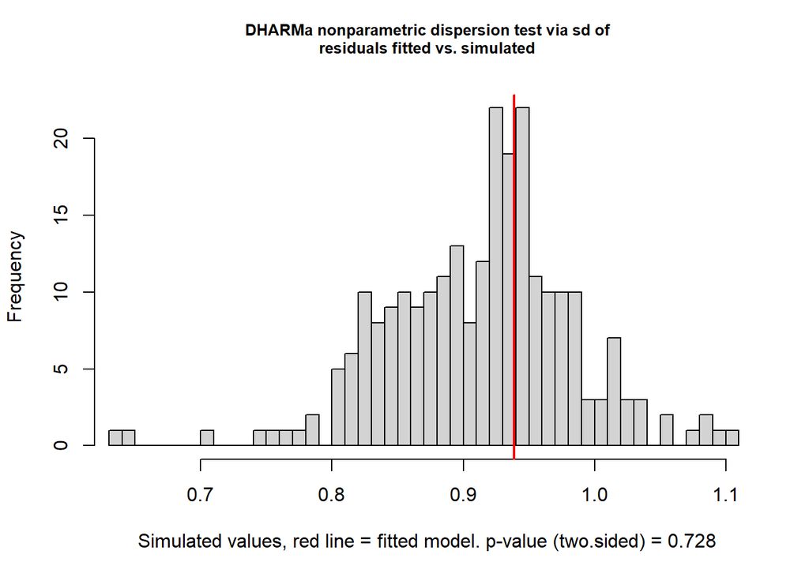

   ```
       DHARMa nonparametric dispersion test via sd of residuals fitted vs.
       simulated

   data:  simulationOutput
   dispersion = 1.0277, p-value = 0.728
   alternative hypothesis: two.sided
   ```

   ```r
   testDispersion(res1) #ok
   ```

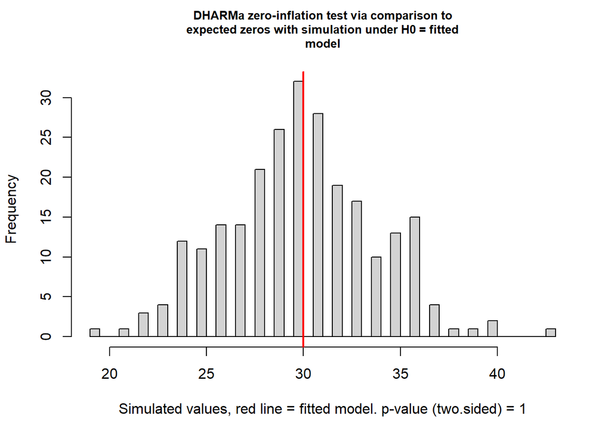

   ```
       DHARMa zero-inflation test via comparison to expected zeros with
       simulation under H0 = fitted model

   data:  simulationOutput
   ratioObsSim = 0.99668, p-value = 1
   alternative hypothesis: two.sided
   ```

   ```r
   testZeroInflation(res1) #ok
   ```

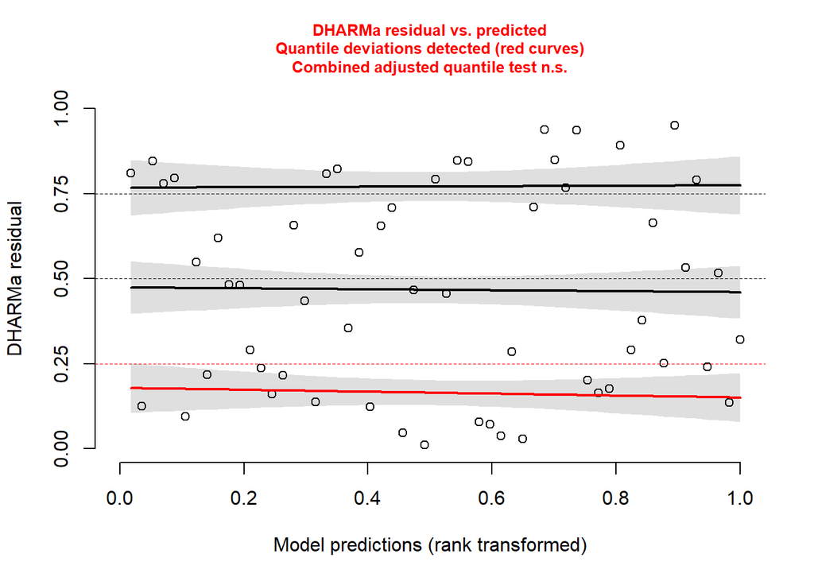

   ```
       Test for location of quantiles via qgam

   data:  res
   p-value = 0.1158
   alternative hypothesis: both
   ```

   ```r
   testQuantiles(res1) #ok
   ```

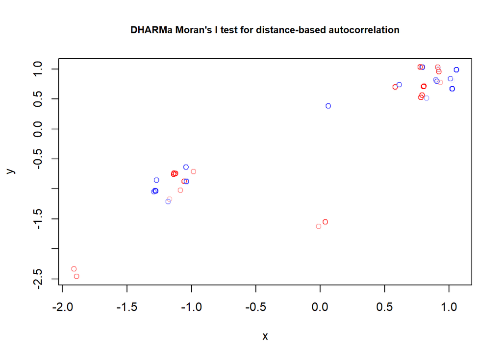

   ```
       DHARMa Moran's I test for distance-based autocorrelation

   data:  res1
   observed = 0.252595, expected = -0.017857, sd = 0.096070, p-value =
   0.004875
   alternative hypothesis: Distance-based autocorrelation
   ```

   ```r
   testSpatialAutocorrelation(res1,x = df$X,y = df$Y) #pas ok, rend la valeur de p trop ''optimiste''
   ```

   Ici, le modèle n’est pas si pire mais n’est pas parfait non plus. Avec certains essaie que je n’ai pas inclus dans ce Quarto, (changement en km, groupe spacial) rien n’a corrigé l’autocorrelation spatiale. Ainsi, nous allons continuer avec ce modèle. Toutefois, une autocorrelation spatiale peu réduire artificiellement le p-value. Donc, il faudra rester prudent lors de l’interprétation.
3. **Analyse** :

   ```r
   summary(mod1)
   ```

   ```
   Call:
   glm(formula = pres ~ Traitement + X + Y, family = binomial(link = "logit"),
       data = df)

   Coefficients:
                   Estimate Std. Error z value Pr(>|z|)
   (Intercept)       0.5202     0.5167   1.007    0.314
   TraitementCJ     -0.8466     0.7039  -1.203    0.229
   TraitementCPPTM  -1.1406     0.7563  -1.508    0.132
   TraitementNAT    -0.3306     1.2034  -0.275    0.784
   X                 1.1535     0.9874   1.168    0.243
   Y                -1.1202     1.0474  -1.069    0.285

   (Dispersion parameter for binomial family taken to be 1)

       Null deviance: 78.861  on 56  degrees of freedom
   Residual deviance: 74.082  on 51  degrees of freedom
   AIC: 86.082

   Number of Fisher Scoring iterations: 4
   ```

   Ici, rien n’est significatif MÊME avec l’autocorrelation spatiale.
4. **Visualisation** :

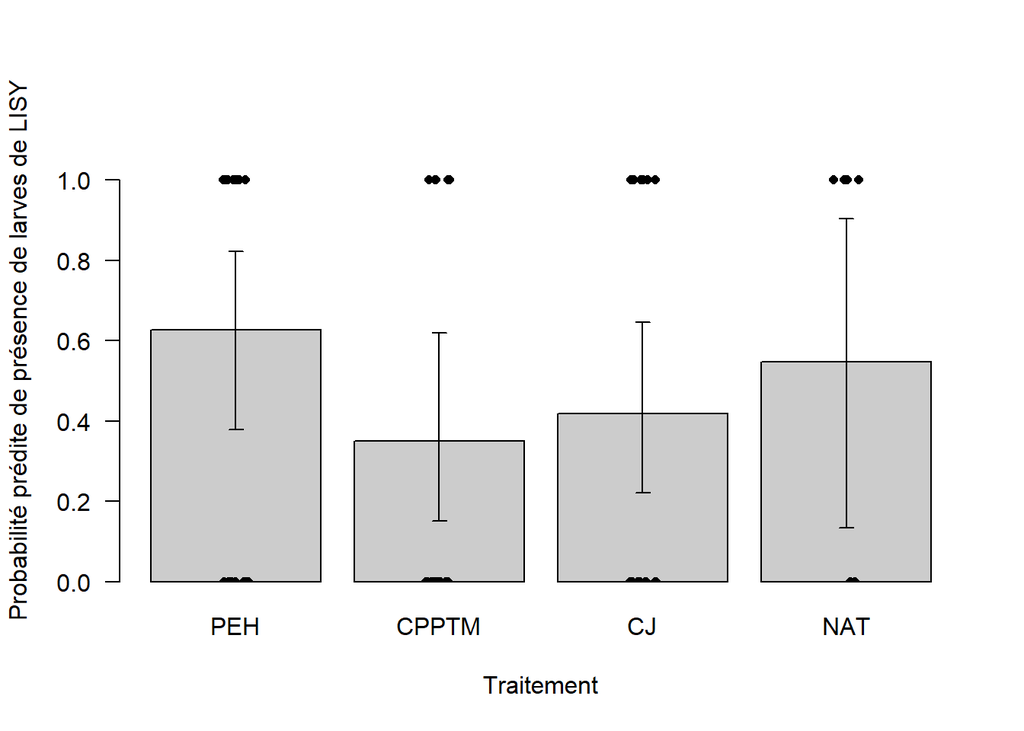

   ```r
   emm_prob <- emmeans(mod1, ~ Traitement, type = "response")
   res <- as.data.frame(emm_prob)
   ordre <- c("PEH", "CPPTM", "CJ", "NAT")
   res <- res[match(ordre, res$Traitement), ]
   moyennes <- res$prob
   inf <- res$asymp.LCL
   sup <- res$asymp.UCL
   jit <- jitter(barres[match(df$Traitement, res$Traitement)],amount = 0.08)

   barres <- barplot(moyennes,
                     names.arg = res$Traitement,
                     ylim = c(0, 1.15),
                     ylab = "Probabilité prédite de présence de larves de LISY",
                     xlab = "Traitement",
                     col = "grey80",
                     border = "black",
                     las = 1)
   set.seed(123)
   points(jit, df$pres,
          pch = 16,
          cex = 0.8,
          col = "black")
   arrows(x0 = barres, y0 = inf,
          x1 = barres, y1 = sup,
          angle = 90, code = 3, length = 0.05)
   ```

n PEH = 17 , n CPPTM = 15, n CJ = 19, NAT = 6

## Résumé visuel presence/absence (Oeufs + Larves)

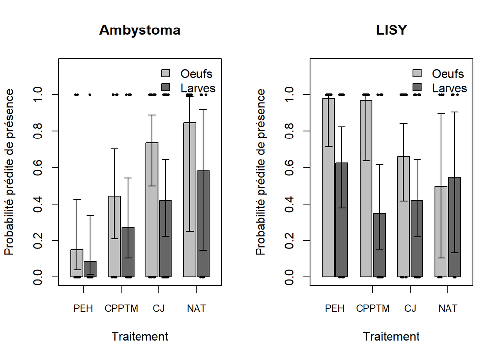

```r
par(mfrow = c(1, 2))

#Ambystomes
ordre <- c("PEH", "CPPTM", "CJ", "NAT")
couleurs <- c("grey75", "grey40")

#1. Probabilités prédites

res_oeufs <- as.data.frame(emmeans(mod2A, ~ Traitement, type = "response"))
res_oeufs <- res_oeufs[match(ordre, res_oeufs$Traitement),]

res_larves <- as.data.frame(emmeans(mod1A, ~ Traitement, type = "response"))
res_larves <- res_larves[match(ordre, res_larves$Traitement),]

#2. Préparer les valeurs
moy_oeufs <- res_oeufs$prob
inf_oeufs <- res_oeufs$asymp.LCL
sup_oeufs <- res_oeufs$asymp.UCL

moy_larves <- res_larves$prob
inf_larves <- res_larves$asymp.LCL
sup_larves <- res_larves$asymp.UCL

# 3. Positions des barres
centre <- 1:4
ecart <- 0.18
pos_oeufs <- centre - ecart
pos_larves <- centre + ecart
largeur <- 0.32

# 4. Créer le graphique
plot(
  NA,
  xlim = c(0.5, 4.5),
  ylim = c(0, 1.15),
  xaxt = "n",
  xlab = "Traitement",
  ylab = "Probabilité prédite de présence",
  main = "Ambystoma")
# Axe des traitements
axis(
  1,
  at = centre,
  labels = ordre,
  las = 1,
  cex.axis = 0.8)
#5. Ajouter les barres
rect(
  xleft = pos_oeufs - largeur / 2,
  ybottom = 0,
  xright = pos_oeufs + largeur / 2,
  ytop = moy_oeufs,
  col = couleurs[1],
  border = "black")

rect(
  xleft = pos_larves - largeur / 2,
  ybottom = 0,
  xright = pos_larves + largeur / 2,
  ytop = moy_larves,
  col = couleurs[2],
  border = "black")


# 6. Ajouter les intervalles de confiance
arrows(
  x0 = pos_oeufs,
  y0 = inf_oeufs,
  x1 = pos_oeufs,
  y1 = sup_oeufs,
  angle = 90,
  code = 3,
  length = 0.05)

arrows(
  x0 = pos_larves,
  y0 = inf_larves,
  x1 = pos_larves,
  y1 = sup_larves,
  angle = 90,
  code = 3,
  length = 0.05)


# 7. Ajouter les observations réelles
set.seed(123)

jit_oeufs <- jitter(pos_oeufs[match(df_oeufsA$Traitement, ordre)], amount = 0.08)
points( jit_oeufs, df_oeufsA$pres, pch = 16, cex = 0.5, col = "black")

jit_larves <- jitter(pos_larves[match(df_larvesA$Traitement, ordre)],amount = 0.08)
points(jit_larves,df_larvesA$pres,pch = 16,cex = 0.5,col = "black")

#8. Légende
legend("topright",legend = c("Oeufs", "Larves"),fill = couleurs,border = "black",bty = "n")

#LISY
ordre <- c("PEH", "CPPTM", "CJ", "NAT")
couleurs <- c("grey75", "grey40")

#1. Probabilités prédites

res_oeufs <- as.data.frame(emmeans(mod1LO, ~ Traitement, type = "response"))
res_oeufs <- res_oeufs[match(ordre, res_oeufs$Traitement),]

res_larves <- as.data.frame(emmeans(mod1L, ~ Traitement, type = "response"))
res_larves <- res_larves[match(ordre, res_larves$Traitement),]

#2. Préparer les valeurs
moy_oeufs <- res_oeufs$prob
inf_oeufs <- res_oeufs$asymp.LCL
sup_oeufs <- res_oeufs$asymp.UCL

moy_larves <- res_larves$prob
inf_larves <- res_larves$asymp.LCL
sup_larves <- res_larves$asymp.UCL

# 3. Positions des barres
centre <- 1:4
ecart <- 0.18
pos_oeufs <- centre - ecart
pos_larves <- centre + ecart
largeur <- 0.32

# 4. Créer le graphique
plot(
  NA,
  xlim = c(0.5, 4.5),
  ylim = c(0, 1.15),
  xaxt = "n",
  xlab = "Traitement",
  ylab = "Probabilité prédite de présence",
  main = "LISY")
# Axe des traitements
axis(
  1,
  at = centre,
  labels = ordre,
  las = 1,
  cex.axis = 0.8)
#5. Ajouter les barres
rect(
  xleft = pos_oeufs - largeur / 2,
  ybottom = 0,
  xright = pos_oeufs + largeur / 2,
  ytop = moy_oeufs,
  col = couleurs[1],
  border = "black")

rect(
  xleft = pos_larves - largeur / 2,
  ybottom = 0,
  xright = pos_larves + largeur / 2,
  ytop = moy_larves,
  col = couleurs[2],
  border = "black")


# 6. Ajouter les intervalles de confiance
arrows(
  x0 = pos_oeufs,
  y0 = inf_oeufs,
  x1 = pos_oeufs,
  y1 = sup_oeufs,
  angle = 90,
  code = 3,
  length = 0.05)

arrows(
  x0 = pos_larves,
  y0 = inf_larves,
  x1 = pos_larves,
  y1 = sup_larves,
  angle = 90,
  code = 3,
  length = 0.05)


# 7. Ajouter les observations réelles
set.seed(123)

jit_oeufs <- jitter(pos_oeufs[match(df_oeufsL$Traitement, ordre)], amount = 0.08)
points( jit_oeufs, df_oeufsL$pres, pch = 16, cex = 0.5, col = "black")

jit_larves <- jitter(pos_larves[match(df_larvesL$Traitement, ordre)],amount = 0.08)
points(jit_larves,df_larvesL$pres,pch = 16,cex = 0.5,col = "black")

#8. Légende
legend("topright",legend = c("Oeufs", "Larves"),fill = couleurs,border = "black",bty = "n")
```

Oeufs et Larves : n PEH = 17 , n CPPTM = 15, n CJ = 19, NAT = 6

**Note:** Selon le summary de ces modèles (non corroboré par emmeans)  
PEH-CJ et PEH-NAT diffèrent pour les oeufs des ambystomes et LISY  
PEH-CJ diffère pour les larves d’ambystomes

Surprenament, on peut voir qu’il y a plus de larves que d’oeufs dans NAT pour LISY. Ceci est dut au fait que des larves ont été trouvé dans l’étang 19FRONT5 alors que cela n’a pas été le cas pour les oeufs (manque de détection des masses d’oeufs).  
Ambystomes sont assez linéaire alors que LISY semble plus quadratique (curve). Le nombre d’oeufs vs le nombre de larve détecté dans le CPPTM est drastiquement différent. Il semblerait que plusieurs masses d’oeufs de LISY ne se pas au stade larvaire dans CPPTM. Pour les LISY, tendance visible (mais fort probablement non significatif) d’avoir autant de présence de larve dans PEH que dans NAT.

### **Suppléments** :

Proportions des étangs qui avaient des oeufs qui se sont rendu au comptage des larves (soit qui c’est rendu lorsque les larves sont assez développées pour avoir des pattes arrières) :

1. Ambystomes + LISY

|  | PEH | CPPTM | CJ | NAT |
| --- | --- | --- | --- | --- |
| nb Étangs avec oeufs | 16 | 15 | 19 | 6 |
| nb Étangs avec larves développées | 10 | 5 | 10 | 4 |
| Proportion (%) | 62,50 | 33,33 | 52,63 | 66,67 |

2. Ambystomes seulement

   |  | PEH | CPPTM | CJ | NAT |
   | --- | --- | --- | --- | --- |
   | nb Étangs avec oeufs | 2 | 6 | 14 | 6 |
   | nb Étangs avec larves développées | 1 | 4 | 8 | 3 |
   | Proportion (%) | 50,00 | 66,67 | 57,14 | 50,00 |

3. LISY seulement

   |  | PEH | CPPTM | CJ | NAT |
   | --- | --- | --- | --- | --- |
   | nb Étangs avec oeufs | 16 | 15 | 13 | 3 |
   | nb Étangs avec larves développées | 10 | 5 | 8 | 4 |
   | Proportion (%) | 62,50 | 33,33 | 61,54 | 133,33 |

   NAT semble avoir de meilleures proportion que PEH malgré la sécheresse (à prendre avec un grain de sel sachant que les n sont vraiment bas pour NAT). CPPTM a parmis les pires proportions, + de prédation ?

## Est-ce que la date de sortie des larves varie selon le type de traitement ?

Plus les larves sortent tardivement de l’étang, plus la qualité de celui-ci devrait être bonne. Ici, on va juste faire LISY puisqu’on a pas assez de métamorphose assurée pour les Ambystomes.

1. **Préparation des données** :

   ```r
   PS <- read_excel("C:/Users/super/Université du Québec en Outaouais/CLAUDIE ÉTANGS VERNAUX - Documents/Stats/Hydro_Survie/LISY_Database_Survie.xlsx", sheet = 1)
   PS <- PS[rowSums(!is.na(PS[, -1])) > 0, ]
   PS[PS == "NA"] <- NA
   PS <- filter(PS, !if_all(-No_etang, is.na))
   PS$No_etang <- as.factor(PS$No_etang)
   PS$AvantDer_prise <- as.numeric(PS$AvantDer_prise)
   PS$Der_prise <- as.numeric(PS$Der_prise)
   PS$Statut <- as.numeric(PS$Statut)
   PS$X <- as.numeric(PS$X)
   PS$Y <- as.numeric(PS$Y)
   PS$X <- as.numeric(scale(PS$X))
   PS$Y <- as.numeric(scale(PS$Y))
   PS$Condition <- as.factor(PS$Condition)
   PS$Traitements <- as.factor(PS$Traitements)
   PS$Traitements <- relevel(PS$Traitements, ref = "PEH")
   PS <- PS[PS$Condition == "meta", ]
   PS
   ```

   ```
   # A tibble: 24 × 8
      No_etang  AvantDer_prise Der_prise Statut Condition Traitements      X      Y
      <fct>              <dbl>     <dbl>  <dbl> <fct>     <fct>        <dbl>  <dbl>
    1 5WATCJ4              177       203      1 meta      CJ          -1.17  -1.05
    2 7WATPEH2             191       203      1 meta      PEH         -1.42  -1.22
    3 12WATPEH5            178       191      1 meta      PEH         -1.30  -1.38
    4 8WATPEH1             191       204      1 meta      PEH         -1.43  -1.24
    5 11WATCPP…            178       191      1 meta      CPPTM       -1.32  -1.42
    6 59WATCJE…            177       190      1 meta      CJ          -1.17  -0.790
    7 57WATPEH…            178       191      1 meta      PEH         -1.42  -1.23
    8 58WATCPP…            177       191      1 meta      CPPTM       -1.41  -1.03
    9 20DORPEH5            169       210      1 meta      PEH          0.993  0.819
   10 23DORPEH…            169       210      1 meta      PEH          1.01   0.789
   # ℹ 14 more rows
   ```

   ```r
   table(PS$Traitements)
   ```

   ```
     PEH    CJ CPPTM   NAT
       7     7     7     3
   ```

   À noter que les n de cet analyse sont extrêmement bas. Si le modèle fonctionne, il faut interpréter les résultats avec beaucoup de précautions.
2. **Choix de l’analyse** :

   ```r
   library(lmtest)
   mod <- lm(AvantDer_prise ~ Traitements + X + Y, data = PS)
   shapiro.test(residuals(mod)) #Normalité ok
   ```

   ```
       Shapiro-Wilk normality test

   data:  residuals(mod)
   W = 0.94287, p-value = 0.1889
   ```

   ```r
   bptest(mod) # Homogénéité ok mais limite
   ```

   ```
       studentized Breusch-Pagan test

   data:  mod
   BP = 10.6, df = 5, p-value = 0.05992
   ```

   L’homogénité est limite, on va essayer de pousser ça plus loin

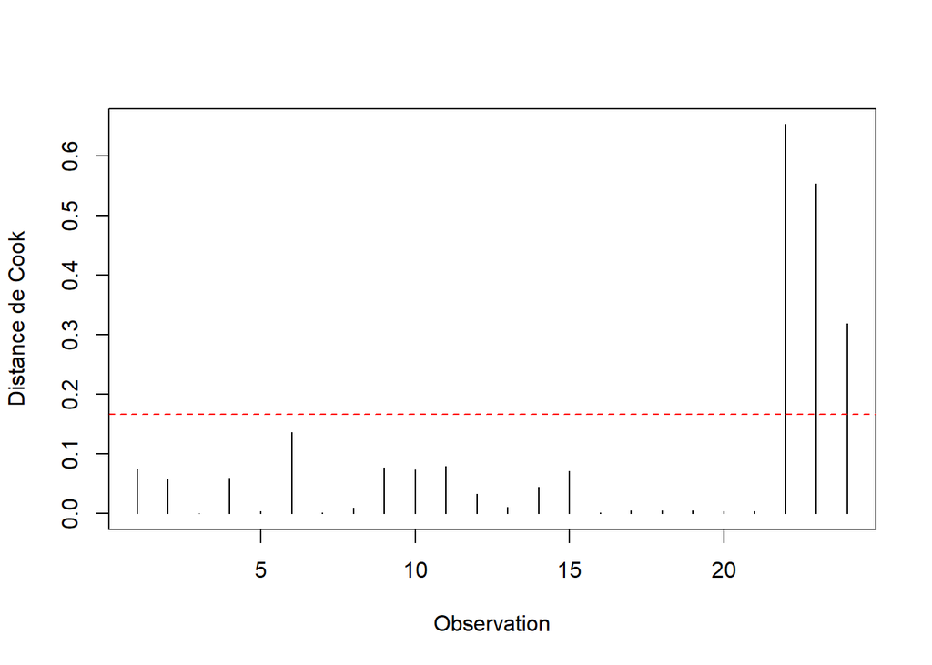

   ```r
   plot(cooks.distance(mod),
        type = "h",
        ylab = "Distance de Cook",
        xlab = "Observation")
   abline(h = 4 / nrow(PS), col = "red", lty = 2)
   ```

   ```r
   which(cooks.distance(mod) > 4/nobs(mod))
   ```

   ```
   22 23 24
   22 23 24
   ```

   ```r
   PS[c(22, 23, 24), ] #Touts des NAT
   ```

   ```
   # A tibble: 3 × 8
     No_etang AvantDer_prise Der_prise Statut Condition Traitements        X      Y
     <fct>             <dbl>     <dbl>  <dbl> <fct>     <fct>          <dbl>  <dbl>
   1 18FRONT5            240        NA      0 meta      NAT         -0.00563  0.322
   2 19FRONT5            211       218      1 meta      NAT         -0.00656  0.319
   3 56MEGEX1            201       212      1 meta      NAT         -0.0850  -1.87
   ```

   Les points de NAT ont une date plus hautes que les autres points. Les points de NAT semble influencer les résidus. En même temps, il est normal que la date de NAT soit plus élevée que les autres sachant que c’est la référence. Puisque ça s’explique biologiquement et que le bptest reste au-dessus de 0.05, je vais garder le modèle comme il est. Toutefois, il faudra attention pour l’interprétation des résultats pour NAT.
3. **Analyse** :

   ```r
   summary(mod) #NAT très significatif!
   ```

   ```
   Call:
   lm(formula = AvantDer_prise ~ Traitements + X + Y, data = PS)

   Residuals:
       Min      1Q  Median      3Q     Max
   -13.912  -6.838   1.050   5.114  15.065

   Coefficients:
                    Estimate Std. Error t value Pr(>|t|)
   (Intercept)       180.373      3.926  45.944  < 2e-16 ***
   TraitementsCJ       7.922      5.629   1.407   0.1764
   TraitementsCPPTM   -1.319      5.575  -0.237   0.8157
   TraitementsNAT     41.057      7.315   5.612 2.52e-05 ***
   X                  -9.016      5.405  -1.668   0.1126
   Y                  10.732      5.522   1.943   0.0678 .
   ---
   Signif. codes:  0 '***' 0.001 '**' 0.01 '*' 0.05 '.' 0.1 ' ' 1

   Residual standard error: 10.17 on 18 degrees of freedom
   Multiple R-squared:  0.6734,    Adjusted R-squared:  0.5827
   F-statistic: 7.423 on 5 and 18 DF,  p-value: 0.000619
   ```

   ```r
   emm <- emmeans(mod, ~ Traitements)
   pairs(emm, adjust = "tukey") #Nat diffère des autres!
   ```

   ```
    contrast    estimate   SE df t.ratio p.value
    PEH - CJ       -7.92 5.63 18  -1.407  0.5110
    PEH - CPPTM     1.32 5.57 18   0.237  0.9952
    PEH - NAT     -41.06 7.32 18  -5.612  0.0001
    CJ - CPPTM      9.24 5.49 18   1.683  0.3606
    CJ - NAT      -33.13 7.39 18  -4.481  0.0015
    CPPTM - NAT   -42.38 7.55 18  -5.611  0.0001

   P value adjustment: tukey method for comparing a family of 4 estimates
   ```

   Même avec la correction de Tukey, les p-value de traitements comparé à NAT sont assez bas.
4. **Visualisation** :

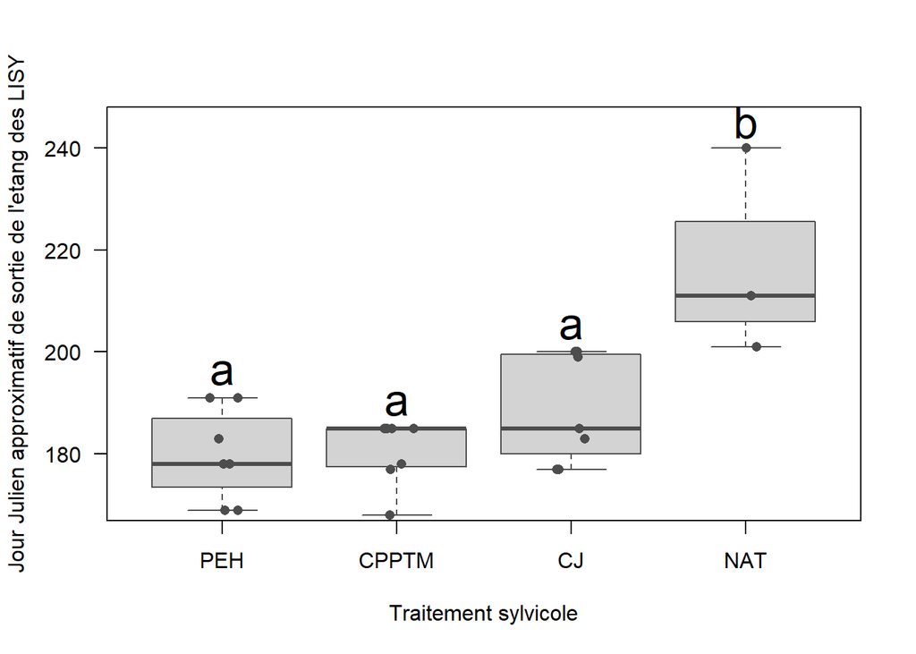

   ```r
   PS$Traitements <- factor(PS$Traitements,levels = c('PEH',"CPPTM", "CJ", "NAT"))
   boxplot(AvantDer_prise ~ Traitements,
           data = PS,
           xlab = "Traitement sylvicole",
           ylab = 'Jour Julien approximatif de sortie de l\'etang des LISY',
           border = "gray30",
           las = 1,
           ylim = c(170, 245))
   stripchart(AvantDer_prise ~ Traitements,
              data = PS,
              vertical = TRUE,
              method = "jitter",
              pch = 16,
              col = "gray30",
              add = TRUE)
   text(x = 2, y = 190, labels = "a", cex = 2) #CPPTM
   text(x = 1, y = 196, labels = "a", cex = 2) #PEH
   text(x = 4, y = 245, labels = "b", cex = 2) #NAT
   text(x = 3, y = 205, labels = "a", cex = 2) #CJ
   ```

n PEH = 7 , n CPPTM = 7, n CJ = 7, NAT = 3

Ici, NAT est probablement significativement plus élevé que les autres traitements. Par contre, avec des n aussi bas, ceci devrait être plutôt interprété comme une tendance sans aucune certitude. Une autre étude avec plus d’étangs serait nécessaire pour confirmer la tendance.

## Est-ce que le succès reproducteur (survit jusqu’à la métamorphose) varie selon le type de traitement ?

| Code | Signification | Rôle |
| --- | --- | --- |
| 1 | Mort | Risque compétitif |
| 2 | Metamorphose | Évènement d’intérêt |
| 3 | Indéterminé | Risque compétitif |
| 0 | Fin de la prise de données | Censure à droite |

1. **Préparation des données:**

   ```r
   PS <- read_excel("C:/Users/super/Université du Québec en Outaouais/CLAUDIE ÉTANGS VERNAUX - Documents/Stats/Hydro_Survie/FineGray_PoolSpecific_Database.xlsx", sheet = 1)
   PS[PS == "NA"] <- NA
   PS <- filter(PS, !if_all(-No_etang, is.na))
   PS$No_etang <- as.factor(PS$No_etang)
   PS$AvantDer_prise <- as.numeric(PS$AvantDer_prise)
   PS$Der_prise <- as.numeric(PS$Der_prise)
   PS$Statut <- as.numeric(PS$Statut)
   PS$Condition <- as.factor(PS$Condition)
   PS$Traitements <- as.factor(PS$Traitements)
   PS
   ```

   ```
   # A tibble: 54 × 6
      No_etang   AvantDer_prise Der_prise Statut Condition Traitements
      <fct>               <dbl>     <dbl>  <dbl> <fct>     <fct>
    1 1WATCJ6                37        NA      3 ind       CJ
    2 2WATCJ5                37        NA      3 ind       CJ
    3 3WATCJ1                51        61      1 mort      CJ
    4 4WATCJ2               110       127      1 mort      CJ
    5 5WATCJ4                93        NA      2 meta      CJ
    6 6WATCJ3               110       128      1 mort      CJ
    7 17WATPEH10             50        NA      3 ind       PEH
    8 7WATPEH2               92        NA      2 meta      PEH
    9 12WATPEH5              80        NA      2 meta      PEH
   10 8WATPEH1               93        NA      2 meta      PEH
   # ℹ 44 more rows
   ```

2. **Analyse :**

```r
library(cmprsk)
PS$Traitements <- relevel(PS$Traitements, ref = "PEH")
Trait2 <- model.matrix(~ Traitements, data = PS)[, -1]
FG_meta2 <- crr(ftime = PS$AvantDer_prise,fstatus = PS$Statut,cov1 = Trait2, failcode=2,cencode=0, maxiter = 100) #code de l'évènement d'intéret =2 métamorphose
FG_meta2$converged #ok
```

```
[1] TRUE
```

```r
summary(FG_meta2)
```

```
Competing Risks Regression

Call:
crr(ftime = PS$AvantDer_prise, fstatus = PS$Statut, cov1 = Trait2,
    failcode = 2, cencode = 0, maxiter = 100)

                   coef exp(coef) se(coef)      z p-value
TraitementsCJ    -0.970     0.379    0.594 -1.633    0.10
TraitementsCPPTM -0.542     0.581    0.620 -0.875    0.38
TraitementsNAT   -1.292     0.275    0.987 -1.309    0.19

                 exp(coef) exp(-coef)   2.5% 97.5%
TraitementsCJ        0.379       2.64 0.1182  1.21
TraitementsCPPTM     0.581       1.72 0.1724  1.96
TraitementsNAT       0.275       3.64 0.0397  1.90

Num. cases = 54
Pseudo Log-likelihood = -59
Pseudo likelihood ratio test = 3.31  on 3 df,
```

```r
PS$Traitements <- relevel(PS$Traitements, ref = "CJ")
Trait2 <- model.matrix(~ Traitements, data = PS)[, -1]
FG_meta2 <- crr(ftime = PS$AvantDer_prise,fstatus = PS$Statut,cov1 = Trait2, failcode=2,cencode=0, maxiter = 100)
FG_meta2$converged #ok
```

```
[1] TRUE
```

```r
summary(FG_meta2)
```

```
Competing Risks Regression

Call:
crr(ftime = PS$AvantDer_prise, fstatus = PS$Statut, cov1 = Trait2,
    failcode = 2, cencode = 0, maxiter = 100)

                   coef exp(coef) se(coef)      z p-value
TraitementsPEH    0.970     2.639    0.594  1.633    0.10
TraitementsCPPTM  0.428     1.534    0.707  0.605    0.54
TraitementsNAT   -0.322     0.725    1.050 -0.306    0.76

                 exp(coef) exp(-coef)   2.5% 97.5%
TraitementsPEH       2.639      0.379 0.8234  8.46
TraitementsCPPTM     1.534      0.652 0.3837  6.13
TraitementsNAT       0.725      1.379 0.0925  5.68

Num. cases = 54
Pseudo Log-likelihood = -59
Pseudo likelihood ratio test = 3.31  on 3 df,
```

```r
PS$Traitements <- relevel(PS$Traitements, ref = "CPPTM")
Trait2 <- model.matrix(~ Traitements, data = PS)[, -1]
FG_meta2 <- crr(ftime = PS$AvantDer_prise,fstatus = PS$Statut,cov1 = Trait2, failcode=2,cencode=0, maxiter = 100)
FG_meta2$converged #ok
```

```
[1] TRUE
```

```r
summary(FG_meta2)
```

```
Competing Risks Regression

Call:
crr(ftime = PS$AvantDer_prise, fstatus = PS$Statut, cov1 = Trait2,
    failcode = 2, cencode = 0, maxiter = 100)

                 coef exp(coef) se(coef)      z p-value
TraitementsCJ  -0.428     0.652    0.707 -0.605    0.54
TraitementsPEH  0.542     1.720    0.620  0.875    0.38
TraitementsNAT -0.750     0.473    1.054 -0.711    0.48

               exp(coef) exp(-coef)   2.5% 97.5%
TraitementsCJ      0.652      1.534 0.1630  2.61
TraitementsPEH     1.720      0.581 0.5102  5.80
TraitementsNAT     0.473      2.116 0.0599  3.73

Num. cases = 54
Pseudo Log-likelihood = -59
Pseudo likelihood ratio test = 3.31  on 3 df,
```

```r
PS$Traitements <- relevel(PS$Traitements, ref = "NAT")
Trait2 <- model.matrix(~ Traitements, data = PS)[, -1]
FG_meta2 <- crr(ftime = PS$AvantDer_prise,fstatus = PS$Statut,cov1 = Trait2, failcode=2,cencode=0, maxiter = 100)
FG_meta2$converged #ok
```

```
[1] TRUE
```

```r
summary(FG_meta2)
```

```
Competing Risks Regression

Call:
crr(ftime = PS$AvantDer_prise, fstatus = PS$Statut, cov1 = Trait2,
    failcode = 2, cencode = 0, maxiter = 100)

                  coef exp(coef) se(coef)     z p-value
TraitementsCPPTM 0.750      2.12    1.054 0.711    0.48
TraitementsCJ    0.322      1.38    1.050 0.306    0.76
TraitementsPEH   1.292      3.64    0.987 1.309    0.19

                 exp(coef) exp(-coef)  2.5% 97.5%
TraitementsCPPTM      2.12      0.473 0.268  16.7
TraitementsCJ         1.38      0.725 0.176  10.8
TraitementsPEH        3.64      0.275 0.526  25.2

Num. cases = 54
Pseudo Log-likelihood = -59
Pseudo likelihood ratio test = 3.31  on 3 df,
```

Ici, les coef sont beau. Les modèles sont stables. Rien est significatif, aucun traitement aurait plus de chances de métamorphoses que les autres.

3. **Visualisation**

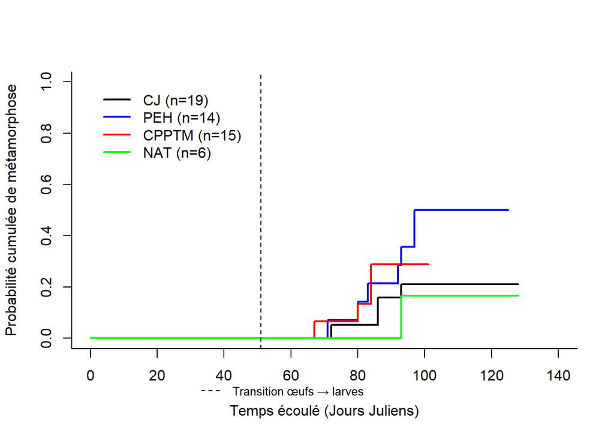

   ```r
   cif3<- with(PS,cuminc( ftime = AvantDer_prise, fstatus = Statut, group = Traitements))
   plot(cif3[c("CJ 2","PEH 2","CPPTM 2","NAT 2")], lwd = 2,lty=rep(1,4),
        color=c('black','blue','red','green'),
        xlab = "Temps écoulé (Jours Juliens)",
        ylab = "Probabilité cumulée de métamorphose",
        xlim=c(0,140),
        curvlab = NA,
        xaxt = "n")
   axis(side = 1,
        at = seq(0,140, by = 20))
   abline(v = 51, lty = 2)
   legend(x=0,y=1,
          legend = c("CJ (n=19)", "PEH (n=14)", "CPPTM (n=15)", "NAT (n=6)"),
          col = c('black','blue','red','green'),
          lwd = 2,
          bg = 'white',
          box.lty=0)
   legend(x=30, y = -0.15,
          legend = "Transition œufs → larves",
          lty = 2,
          bty = "n",
          xpd = TRUE,
          cex=0.8)
   ```

Bien que non significatif, on voit ici la même tendance. Il semblerait que les chances de métamorphoses dans PEH est relativement plus élevée que les autres. Surpenament, c’est NAT qui a le moins de chances. Ceci est probablement dut que 3 de mes 6 échantillons sont morts à cause de l’année exceptionnellement sèche.

4. **Réflexion :**

   La littérature semble expliquer qu’une mortalité élevée du recrutement durant les années de sécheresse serait relativement normal. C’est pourquoi que les ambystomes et LISY pondent non seulement dans les étangs vernaux mais aussi dans les étangs permanants. C’est juste que, si l’année est plus humide, ceux qui ont opté pour pondre dans les étangs vernaux auraient plus de succès reproducteur que ceux qui ont pondu dans des étangs permanants qui ont des prédateurs.  
   En 2025, on a une situation de sécheresse, ce qui explique les résultats de l’analyse de Fine-Gray. Ceci est inquiétant pour le futur des amphibiens forestier puisqu’on prédit une météo de plus en plus instable avec les changements climatiques. Les PEH pourraient être utiles pour les LISY dans le futur avec un climat moins stable, mais la situation est plus inquiétante pour les ambystomes…

# Conclusion :

Pour les Ambystomes, les chances de présence des oeufs et larves semblent augmenter quasi linéairement avec la diminution du niveau de perturbation occasionné par le traitement (les traitements moins invasifs (NAT et CJ) performant le mieux). Il reste que la présence est plus élevée dans les traitements NAT (cannopée encore plus fermée ? Pas d’ornières ? Moins de dérangement anthropiques ? Toutes ces théories explique bien pourquoi les PEH ne sont pas adaptés pour cette espèce)  
Du côté des LISY, la présence d’oeufs et de larves sont presque égales dans les NAT ce qui suggère de bonnes chances d’éclosion. Ceci n’est pas observé dans les autres traitements. Dans les PEH, la prédation des oeufs par les têtards de grenouilles vertes expliquerait bien les pertes. La différence la plus grande se trouve dans le CPPTM. Pour les CPPTM, l’hydropériode est l’une des plus longues et il y a aussi présence de grenouilles vertes…autre cause de la perte des larves (j’ai vu de la prédation par les ratons laveurs, CPPTM + ouvert donc plus de ratons? rien de confirmé). En fin de compte, même si les PEH ont une grande présence d’oeufs, la présence de larve reviens presque au même que ce qu’on trouve dans les NAT malgré l’hydropériode courte des NAT (Nat = bonne survit des larves?).

Un résultat qui a été non attendu: aucun traitement n’est ressortis significatif pour l’effort de reproduction (Densité des oeufs). La littérature semble indiquer que les ambystomes et les ambystomes auraient tendance à donner plus grand effort de reproduction dans les milieux à canopée fermée (Ici ce serait CJ et NAT), mais rien de trop intéressant est ressortie de mon analyse.

Bien que la mortalité dut à l’hydropériode est élevée dans les NAT, dans les quelques étangs de NAT qui ont conservé leur eau, les LISY ont peut-être pris beaucoup plus de temps avant de sortir par métamorphose (je dis peut-être puisque les n de cette analyse sont très bas). Ceci est intéressant, surtout sachant que les étangs des PEH gardent l’eau très longtemps mais, dans les PEH, les LISY ont décidé de sortir tout de même rapidement. La présence de larve de grenouilles vertes dans les PEH pourrait en être la cause (prédation / compétition). Ceci souligne que, même avec une hydropériode similaire, la qualité des étangs NAT pourraient être plus élevée que dans les PEH pour les amphibiens dépendants des étangs vernaux.

Avec les analyses de Fine-Gray, on voit que la probabilité de métamorphose a tendance à être plus élevée dans les PEH (quoi que non significatif). Ceci est probablement dut à l’hydropériode exceptionnellement longue dans les PEH (du moins, lorsque la plantation est jeune). Les dépressions créés par la machinerie ont le potentiel d’aider au recrutement des anoures mais pas pour les ambystomes (du moins, lorsque jeune). Le facteur limitant les chances de métamorphoses n’est pas nécessairement la compétition / prédation par les autres espèces (grenouille vertes et rainette crucifère) puisque celles-ci sont très présentes dans les PEH. En fait, c’est probablement l’hydropériode.